# BeatAML: Hierarchical Clustering

Emily Schwenger

9/15/2021

*Source:* https://uc-r.github.io/hc_clustering

## Step 0: Load libraries

```r
library(tidyverse)  # data manipulation
library(dplyr)
library(tidylog)
library(cluster)    # clustering algorithms
library(factoextra) # clustering visualization
library(dendextend) # for comparing two dendrograms
library(here)
library(ggplot2)
library(ggpubr)
```

## Step 1: Clean data

```r
## Read in raw counts beatAML data ##
mx <- read.csv("~/Desktop/Emily/beatAML/BeatAML_RNASeq_rawcounts_2018_10_24.csv", sep = ",", header = T)
clin <- read.csv("~/Desktop/Emily/beatAML/All_sample_data.csv", sep = ",", header = T)
# var <- read.csv("~/Desktop/Emily/beatAML/All_variants_formatted.csv", sep = ",", header = T)
dim(mx)
```

```
## [1] 63677   503
```

```r
# [1] 63677   503
dim(clin)
```

```
## [1] 702  50
```

```r
# [1] 702  50
# dim(var)
# [1] 1406   32
```

```r
## Format expression matrix
dat <- mx[ , c(10:ncol(mx))]
rownames(dat) <- make.unique(mx$Symbol)
colnames(dat) <- gsub(pattern = "X", replacement = "", colnames(dat))
colnames(dat) <- gsub(pattern = "\\.", replacement = "-", colnames(dat))
# knitr::kable(dat[1:5, 1:5])
```

```r
# Subset data
table(clin$SpecimenType)
```

```
##
##       Bone Marrow Aspirate Healthy, Individual BM MNC
##                        373                         20
##  Healthy, Individual CD34+      Healthy, pooled CD34+
##                          1                         12
##              Leukapheresis           Peripheral Blood
##                         13                        283
```

```r
table(clin$FAB_BlastMorphology)
```

```
##
## Healthy, Individual BM MNC  Healthy, Individual CD34+
##                         20                          1
##      Healthy, pooled CD34+                         M0
##                         12                         10
##                         M1                         M2
##                         15                         13
##                         M3                         M4
##                         11                         35
##                       M4eo                         M5
##                          2                         32
##                        M5a                        M5b
##                          3                          1
##                         M7                        N/A
##                          2                        528
##                        NOS
##                         17
```

```r
# idx <- clin$LLS_SampleID[clin$SpecimenType %in% c("Healthy, Individual BM MNC", "Healthy, Individual CD34+", "Healthy, pooled CD34+")]
# dat <- dat[ , colnames(dat) %in% idx]
idx <- clin$LLS_SampleID[clin$FAB_BlastMorphology %in% c("M4", "M5", "Healthy, Individual BM MNC")]
dat <- dat[ , colnames(dat) %in% idx]
dim(dat)
```

```
## [1] 63677    73
```

Eliminate outliers from previous clustering…

```r
## Blacklist
idx.out <- c("17-00053", "17-00056", "12-00301", "15-00742")
idx.out2 <- c("17-00035", "17-00036", "17-00037") # form light blue cluster away from main healthy BM MNC group, only slightly though
# when clustering with M45 and healthy controls
# 17-00053 is the only healthy individual CD34+; 17-00056 is a major outlier upon clustering
# 15-00742 is a PML-RARa sample that was a major outlier when plotted with M0-5
dat <- dat[, !(colnames(dat) %in% c(idx.out, idx.out2))]
dim(dat)
```

```
## [1] 63677    68
```

```r
# dat[1:5, 1:5]## To keep in mind for later...
# c("15-00595", "15-00692", "14-00464") # interesting cluster (M0-5 clustering); VERY high blast %, 595 = MLL-KMT2A
```

```r
## Remove zero and low counts
all(rowSums(dat) > 0) # FALSE
```

```
## [1] FALSE
```

```r
dat <- dat[rowSums(dat)>0 , ] # eliminate 0's
ct <- apply(dat, 1, function(x,ct){ sum(x >= ct) }, ct=1) # return number of samples with > 0 counts
dat <- dat[ct >= .75 * ncol(dat) , ] # keep the genes with at least 75% of their samples greater than 1.
all(rowSums(dat) > 0) # now returns TRUE :)
```

```
## [1] TRUE
```

```r
dim(dat)
```

```
## [1] 23257    68
```

```r
# [1] 22889   494
knitr::kable(head(dat))
```

|  | 12-00023 | 12-00066 | 12-00258 | 12-00294 | 13-00028 | 13-00118 | 13-00123 | 13-00163 | 13-00195 | 13-00232 | 13-00255 | 13-00331 | 13-00396 | 13-00409 | 13-00487 | 13-00513 | 13-00659 | 14-00012 | 14-00041 | 14-00092 | 14-00135 | 14-00152 | 14-00175 | 14-00184 | 14-00228 | 14-00259 | 14-00447 | 14-00476 | 14-00567 | … |
| --- | --- | --- | --- | --- | --- | --- | --- | --- | --- | --- | --- | --- | --- | --- | --- | --- | --- | --- | --- | --- | --- | --- | --- | --- | --- | --- | --- | --- | --- | --- |
| TSPAN6 | 8 | 2 | 0 | 0 | 0 | 4 | 0 | 2 | 2 | 1 | 5 | 12 | 0 | 1 | 0 | 6 | 0 | 8 | 42 | 20 | 8 | 5 | 23 | 0 | 2 | 4 | 0 | 0 | 0 | … |
| DPM1 | 1080 | 664 | 921 | 955 | 1050 | 831 | 678 | 1875 | 863 | 998 | 777 | 1037 | 1196 | 932 | 836 | 1386 | 823 | 961 | 884 | 1327 | 977 | 1488 | 1095 | 1016 | 789 | 640 | 977 | 1133 | 1220 | … |
| SCYL3 | 701 | 300 | 491 | 1198 | 894 | 880 | 443 | 854 | 585 | 635 | 612 | 645 | 566 | 569 | 631 | 690 | 430 | 335 | 242 | 897 | 570 | 604 | 519 | 735 | 865 | 503 | 532 | 602 | 1673 | … |
| C1orf112 | 249 | 317 | 257 | 577 | 481 | 430 | 245 | 1060 | 286 | 381 | 250 | 222 | 305 | 401 | 456 | 775 | 283 | 220 | 150 | 459 | 393 | 407 | 181 | 767 | 366 | 306 | 785 | 772 | 314 | … |
| FGR | 29052 | 25829 | 31518 | 8188 | 2541 | 6961 | 30514 | 26657 | 23104 | 9594 | 30333 | 1165 | 20920 | 24134 | 17759 | 8056 | 19194 | 11878 | 7915 | 20797 | 19221 | 5366 | 14476 | 4545 | 14111 | 29013 | 7812 | 8856 | 6505 | … |
| CFH | 172 | 135 | 954 | 73 | 32 | 253 | 500 | 103 | 19 | 22 | 161 | 27 | 520 | 954 | 22 | 36 | 357 | 322 | 449 | 228 | 94 | 410 | 158 | 0 | 39 | 33 | 8 | 3168 | 17 | … |

```r
# knitr::kable(tail(dat))
```

```r
## Manually normalize data
libsizes <- colSums(dat)
sizeFactors <- libsizes/mean(libsizes)
log.counts <- log2(dat/sizeFactors + 1)
dat <- log.counts
knitr::kable(dat[1:5, 1:5])
```

|  | 12-00023 | 12-00066 | 12-00258 | 12-00294 | 13-00028 |
| --- | --- | --- | --- | --- | --- |
| TSPAN6 | 3.217872 | 1.864855 | 0.000000 | 0.000000 | 0.000000 |
| DPM1 | 10.479629 | 9.638980 | 10.149222 | 9.915635 | 10.163942 |
| SCYL3 | 9.717116 | 8.533611 | 8.957268 | 10.354025 | 10.192215 |
| C1orf112 | 8.265591 | 8.327620 | 8.137268 | 9.561189 | 8.237016 |
| FGR | 14.841183 | 14.783266 | 15.330774 | 12.321910 | 11.641144 |

To perform a cluster analysis in R, generally, the data should be prepared as follows:

- *Rows* are **observations (individuals)** and *columns* are **variables**
- Any missing value in the data must be removed or estimated (completed above).
- The data must be standardized (i.e., **scaled**) to make variables comparable. Recall that, standardization consists of transforming the variables such that they have **mean zero** and **standard deviation one.**

```r
df <- t(dat) %>% scale()
knitr::kable(df[1:5, 1:5], caption = "Scaled Data")
```

Scaled Data

|  | TSPAN6 | DPM1 | SCYL3 | C1orf112 | FGR |
| --- | --- | --- | --- | --- | --- |
| 12-00023 | 0.4934363 | 0.6022032 | 0.3207683 | -0.8069657 | 0.6485081 |
| 12-00066 | -0.2220291 | -1.0281455 | -1.7105455 | -0.7128415 | 0.5984414 |
| 12-00258 | -1.2081509 | -0.0385852 | -0.9833996 | -1.0016863 | 1.0717408 |
| 12-00294 | -1.2081509 | -0.4916028 | 1.4139308 | 1.1590066 | -1.5293046 |
| 13-00028 | -1.2081509 | -0.0100371 | 1.1362071 | -0.8503266 | -2.1178009 |

```r
mean(df[,1]) # should be 0
```

```
## [1] -8.639178e-17
```

```r
sd(df[,1]) # should be 1
```

```
## [1] 1
```

## Step 2: Hierarchical Clustering with R

There are different functions available in R for computing hierarchical clustering. The commonly used functions are:

- hclust [in stats package] and agnes [in cluster package] for agglomerative hierarchical clustering (HC)
- diana [in cluster package] for divisive HC

### Agglomerative Hierarchical Clustering

We can perform agglomerative HC with hclust. First we compute the dissimilarity values with dist and then feed these values into hclust and specify the agglomeration method to be used (i.e. “complete”, “average”, “single”, “ward.D”). We can then plot the dendrogram.

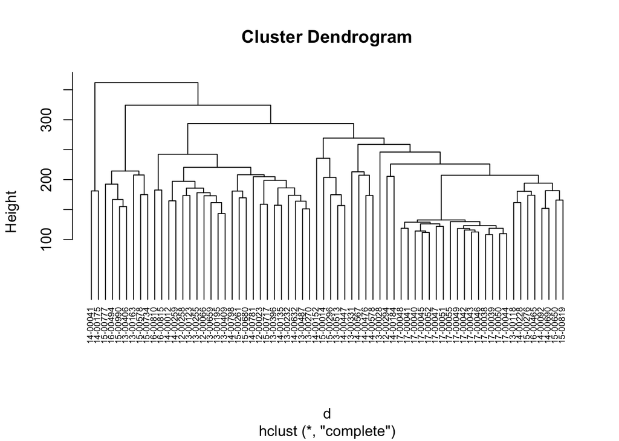

```r
# Dissimilarity matrix
d <- dist(df, method = "euclidean")

# Hierarchical clustering using Complete Linkage
hc1 <- hclust(d, method = "complete" )

# Plot the obtained dendrogram
plot(hc1, cex = 0.6, hang = -1)
```

Alternatively, we can use the agnes function. These functions behave very similarly; however, with the agnes function you can also get the agglomerative coefficient, which measures the amount of clustering structure found (values closer to 1 suggest strong clustering structure).

```r
# Compute with agnes
# hc2 <- agnes(df, method = "complete")

# Agglomerative coefficient
# hc2$ac
```

This allows us to find certain hierarchical clustering methods that can identify stronger clustering structures. Here we see that Ward’s method identifies the strongest clustering structure of the four methods assessed.

```r
# methods to assess
m <- c( "average", "single", "complete", "ward")
names(m) <- c( "average", "single", "complete", "ward")

# function to compute coefficient
ac <- function(x) {
  agnes(df, method = x)$ac
}

map_dbl(m, ac)
```

```
##   average    single  complete      ward
## 0.4144236 0.2446011 0.5558229 0.7478564
```

Ward appears to perform best, so we will use it moving forward.

Similar to before we can visualize the dendrogram:

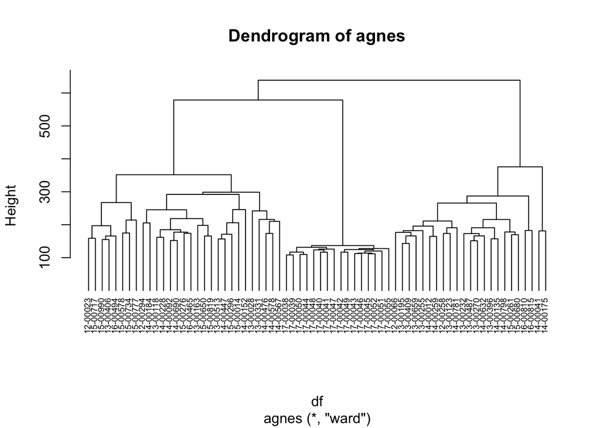

```r
hc3 <- agnes(df, method = "ward")
pltree(hc3, cex = 0.6, hang = -1, main = "Dendrogram of agnes")
```

## Divisive Hierarchical Clustering

The R function diana provided by the cluster package allows us to perform divisive hierarchical clustering. diana works similar to agnes; however, there is no method to provide.

```r
# compute divisive hierarchical clustering
hc4 <- diana(df)

# Divise coefficient; amount of clustering structure found
hc4$dc
```

```
## [1] 0.5460645
```

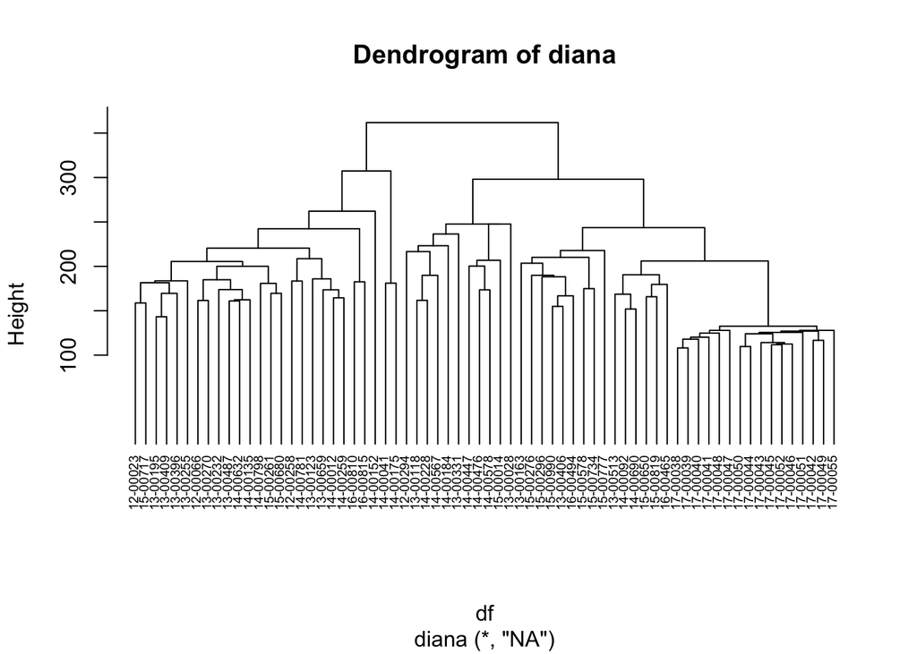

```r
## [1] 0.8514345

# plot dendrogram
pltree(hc4, cex = 0.6, hang = -1, main = "Dendrogram of diana")
```

## Working with Dendrograms

In the dendrogram displayed above, each leaf corresponds to one observation. As we move up the tree, observations that are similar to each other are combined into branches, which are themselves fused at a higher height.

The height of the fusion, provided on the vertical axis, indicates the (dis)similarity between two observations. The higher the height of the fusion, the less similar the observations are. Note that, conclusions about the proximity of two observations can be drawn only based on the height where branches containing those two observations first are fused. We cannot use the proximity of two observations along the horizontal axis as a criteria of their similarity.

The height of the cut to the dendrogram controls the number of clusters obtained. It plays the same role as the k in k-means clustering. In order to identify sub-groups (i.e. clusters), we can cut the dendrogram with cutree:

```r
# Ward's method
hc5 <- hclust(d, method = "ward.D2" )

# Cut tree into 4 groups
sub_grp <- cutree(hc5, k = 4)

# Number of members in each cluster
table(sub_grp)
```

```
## sub_grp
##  1  2  3  4
## 29 21  2 16
```

We can also use the cutree output to add the the cluster each observation belongs to to our original data.

```r
# df <- df %>%
#   mutate(cluster = sub_grp)

#write.table(sub_grp, "beatAML_clusters.tsv", sep = "\t", row.names = T, quote = F)
```

It’s also possible to draw the dendrogram with a border around the 4 clusters. The argument border is used to specify the border colors for the rectangles:

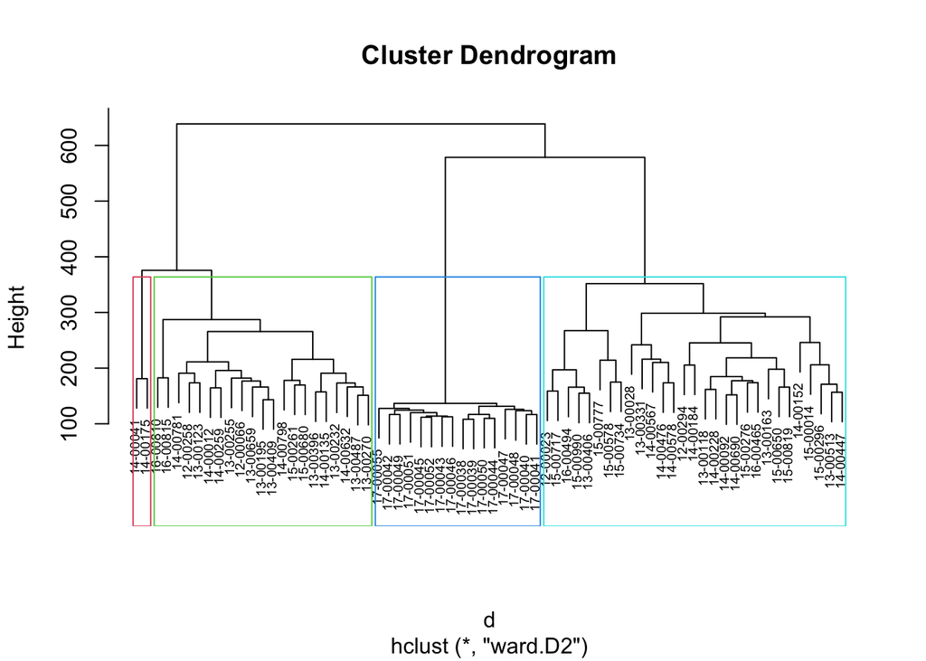

```r
plot(hc5, cex = 0.6)
rect.hclust(hc5, k = 4, border = 2:5)
```

As we saw in the k-means tutorial, we can also use the fviz_cluster function from the factoextra package to visualize the result in a scatter plot.

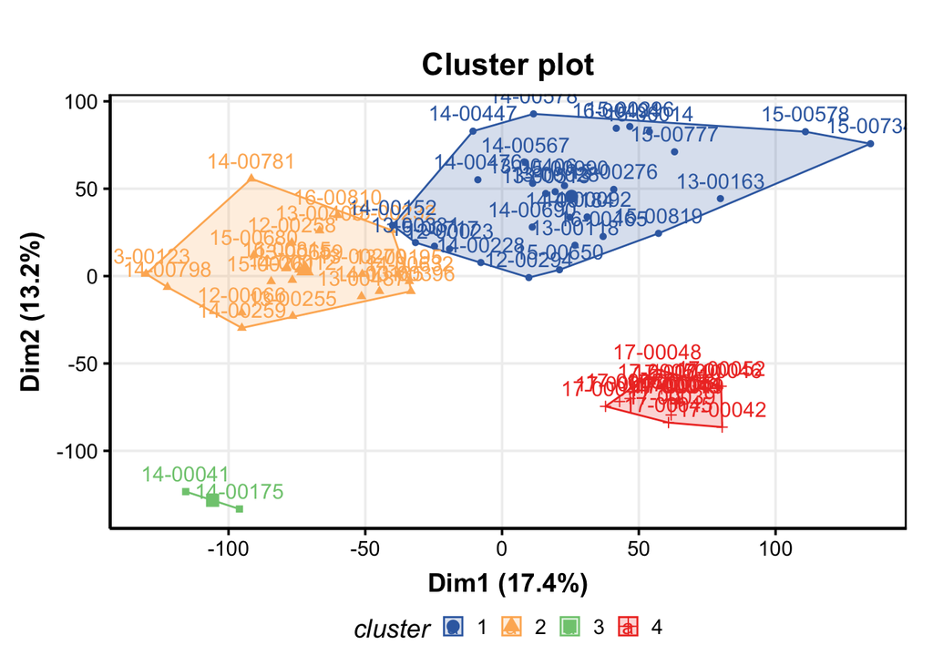

```r
fviz_cluster(list(data = df, cluster = sub_grp), ggtheme = theme_Publication()) +
  scale_color_manual(values = pub.colors) +
  scale_fill_manual(values = pub.colors)
```

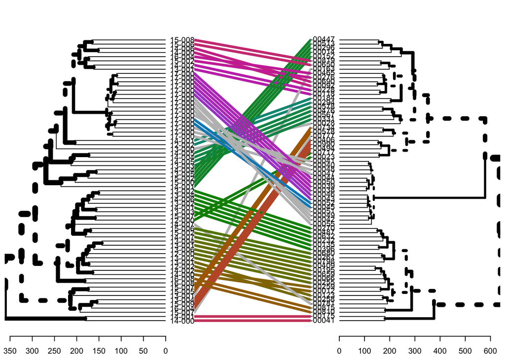

```r
library(dendextend)
# Compute distance matrix
res.dist <- dist(df, method = "euclidean")

# Compute 2 hierarchical clusterings
hc1 <- hclust(res.dist, method = "complete")
hc2 <- hclust(res.dist, method = "ward.D2")

# Create two dendrograms
dend1 <- as.dendrogram (hc1)
dend2 <- as.dendrogram (hc2)

tanglegram(dend1, dend2)
```

## Determine optimal clusters

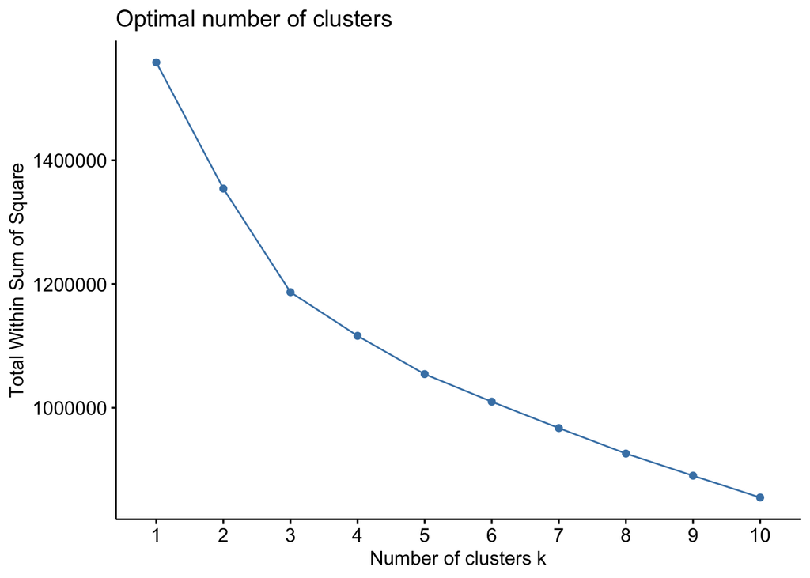

```r
fviz_nbclust(df, FUN = hcut, method = "wss") # elbow
```

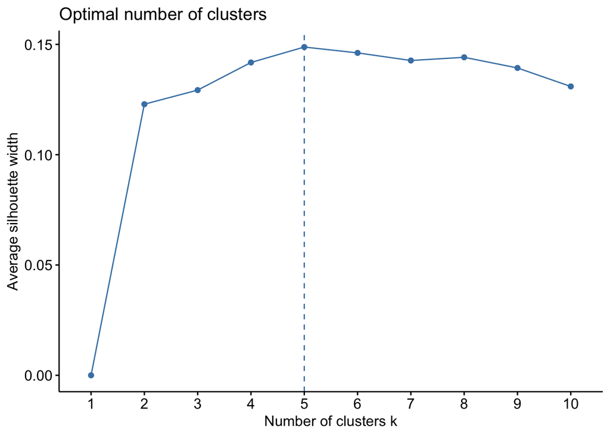

```r
fviz_nbclust(df, FUN = hcut, method = "silhouette") # silhouette
```

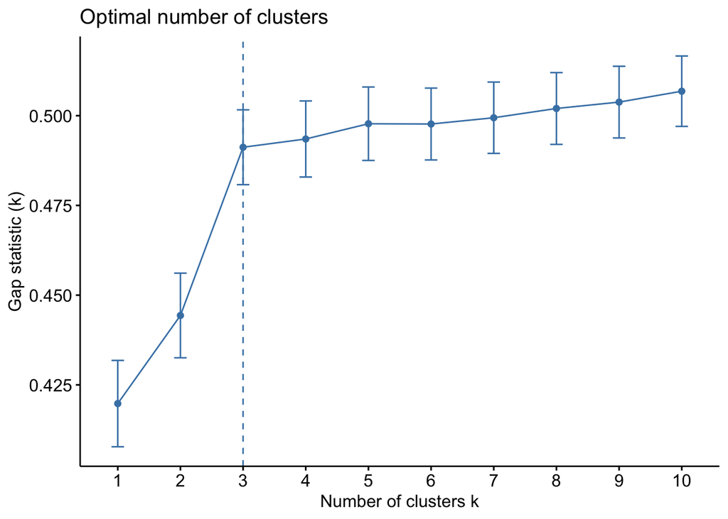

```r
gap_stat <- clusGap(df, FUN = hcut, nstart = 25, K.max = 10, B = 50) # gap statistic
fviz_gap_stat(gap_stat)
```

To use cutree with agnes and diana you can perform the following:

```r
# Cut agnes() tree into n groups
hc_a <- agnes(df, method = "ward")
sub_grp <- cutree(as.hclust(hc_a), k = 3)
write.table(sub_grp, "beatAML_ward_clusters.tsv", sep = "\t", row.names = T, quote = F)

# Cut diana() tree into n groups
hc_d <- diana(df)
cutree(as.hclust(hc_d), k = 3)
```

```
## 12-00023 12-00066 12-00258 12-00294 13-00028 13-00118 13-00123 13-00163
##        1        1        1        2        2        2        1        2
## 13-00195 13-00232 13-00255 13-00331 13-00396 13-00409 13-00487 13-00513
##        1        1        1        2        1        1        1        2
## 13-00659 14-00012 14-00041 14-00092 14-00135 14-00152 14-00175 14-00184
##        1        1        3        2        1        1        3        2
## 14-00228 14-00259 14-00447 14-00476 14-00567 14-00578 14-00632 14-00690
##        2        1        2        2        2        2        1        2
## 14-00781 14-00798 15-00014 15-00261 15-00276 15-00296 15-00578 15-00650
##        1        1        2        1        2        2        2        2
## 15-00680 15-00717 15-00734 15-00777 15-00819 15-00990 16-00465 13-00270
##        1        1        2        2        2        2        2        1
## 16-00494 13-00406 16-00810 16-00815 17-00038 17-00039 17-00048 17-00050
##        2        2        1        1        2        2        2        2
## 17-00040 17-00041 17-00042 17-00043 17-00044 17-00045 17-00046 17-00047
##        2        2        2        2        2        2        2        2
## 17-00049 17-00051 17-00052 17-00055
##        2        2        2        2
```

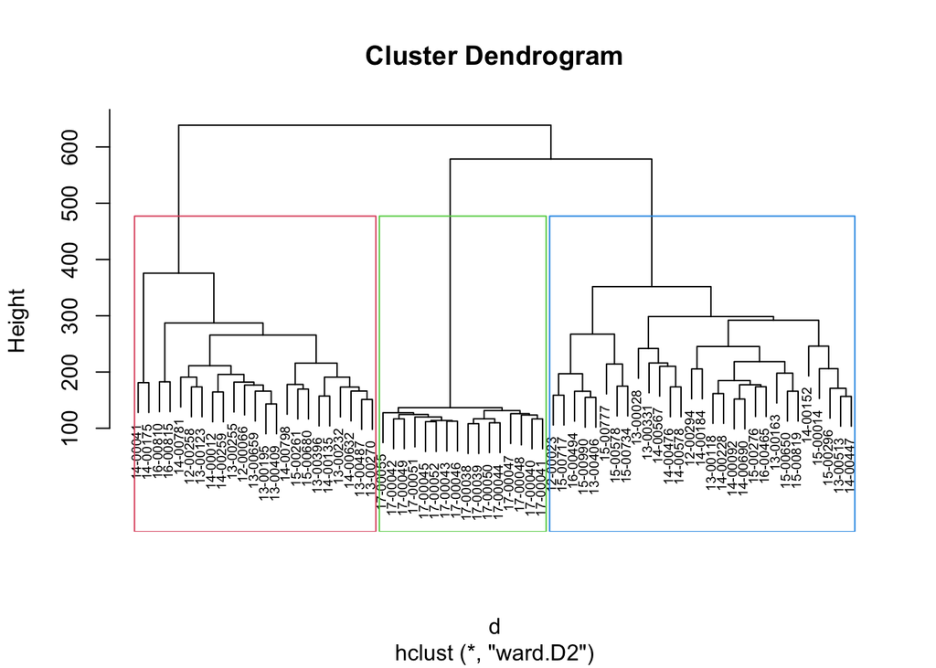

```r
hc5 <- hclust(d, method = "ward.D2" )
plot(hc5, cex = 0.6)
rect.hclust(hc5, k = 3, border = 2:5)
```

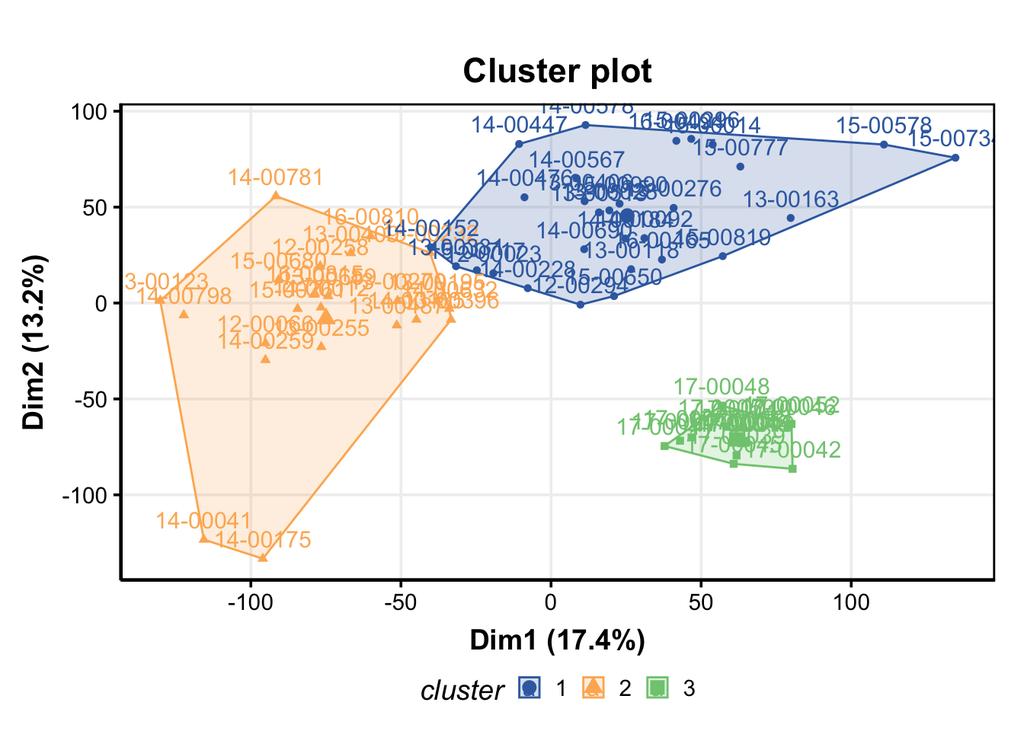

```r
fviz_cluster(list(data = df, cluster = sub_grp), ggtheme = theme_Publication()) +
  scale_color_manual(values = pub.colors) +
  scale_fill_manual(values = pub.colors)
```